# Tests asintóticos para una proporción

14 de julio de 2020

1. Una ruleta tiene números del 0 al 39. Un inspector de casinos sospecha que los números bajos ocurren con mayor frecuencia. Para corroborarlo tira en forma independiente 108 veces una bolilla y cuenta la candidad de resultados que caen entre 0 y 9.

a$)$ De los 108 tiros se observan 40 resultados menores o iguales a 9. Plantear el test de hipótesis para verificar si es cierta la sospecha del inspector y decidir si hay evidencia suficiente para rechazar la hipótesis nula a nivel asintótico 0.06.

b$)$ Cuál es la potencia del test hallado en a$)$ cuando la verdadera probabilidad de que salga un número entre 0 y 9 es 0.36?

**Resolución**

- Variables aleatorias involucradas en el test:

$$X_i=\left\{\begin{array}{ll}
1 &\text{ si el } i-\text{ésimo resultado fue menor o igual a 9}\\
0 &\text{ si no }
\end{array} \right.$$

$X_i$ son i.i.d.

$X_i\sim B(1,p)$

$p$ es la verdadera probabilidad de que salga un resultado menor o igual a 9.

Si la ruleta está equilibrada, $p=1/4$

- Hipótesis $H_0:p= 0.25 \text{ vs } H_1:p>0.25$

  Recordar: $H_1$ es la hipótesis del investigador, es decir, lo que se quiere demostrar.
- Estadístico del test:

  $$\hbox{ }Z:=\frac{\widehat p - 0.25}{\sqrt{0.25(1-0.25)/108}}\underset{%
  \begin{array}
  [c]{c}%
  \uparrow\\
  \text{Bajo $H_0$}
  \end{array}
  }{ \buildrel{a}\over\approx}
  \mathcal N(0,1)$$

donde $\hat p = \overline X$

- Región de rechazo de nivel $\alpha$
  $$\begin{eqnarray*}\mathcal R=\left\{Z\geq z_{\alpha}\right\}&=&
  \left\{\frac{\widehat p - 0.25}{\sqrt{0.25(1-0.25)/n}}\geq z_{\alpha}\right\}\\
  %&=&\left\{\widehat p_n\geq p_0+z_{\alpha}\sqrt{p_0(1-p_0)/108}\right\}
  \end{eqnarray*}$$
- p-valor: $P(Z\geq Z_{\hbox{obs}})$=1-pnorm($Z_{\hbox{obs}}$)
- Calculo $Z_{obs}$ y me fijo si cae en la región de rechazo:

$$Z_{obs}= \frac{ 0.37 - 0.25}{\sqrt{0.25(1-0.25)/108}} =2.89$$

$Z_{obs}>z_{\alpha}$ por lo tanto estamos en la región de rechazo

- Calculo el p-valor:

$P(Z\geq Z_{\hbox{obs}})$=1-pnorm($2.89$) = 0.0019

- Conclusión

Como $Z_{obs}>z_{0.06}$, rechazo $H_0$ a nivel $0.06$.

A la misma conclusión se llega mirando el p-valor :

Como el p-valor<$0.06$, rechazo $H_0$ a nivel $0.06$

Hay evidencia, a nivel $0.06$ de que los números bajos ocurren con mayor frecuencia.

En R

```r
phat <- 40/108
p0 <- 0.25
n <- 108
zobs <- (phat-p0)/sqrt(p0*(1-p0)/n)
zobs
```

```
## [1] 2.888889
```

```r
zalpha <- qnorm(0.95)
zobs>zalpha
```

```
## [1] TRUE
```

```r
pvalor <- 1-pnorm(zobs)
pvalor
```

```
## [1] 0.001933028
```

b$)$ Tenemos que calcular la probabilidad de rechazar $H_0$ cuando el verdadero $p$ es 0.36.

Uno nunca sabe cuál es el verdadero $p$ pero es razonable preguntarse, ¿si el verdadero $p$ fuera 0.36, cuál sería la probabilidad de que este test detecte que los números bajos salen con mayor frecuencia?

$$\pi(0.36) = P_{0.36}(\text{ rechazar } H_0)$$
$$= P_{0.36} \left(\frac{\widehat p - 0.25}{\sqrt{0.25(1-0.25)/108}}\geq 1.55\right)$$

$$= P_{0.36} \left(\widehat p \geq 1.55 \sqrt{0.25(1-0.25)/108}+ 0.25 \right)$$
Ahora “estandarizo” usando el $p$ correcto

$$= P_{0.36} \left(\frac{\widehat p - 0.36}{\sqrt{0.36(1-0.36)/108}} \geq \frac{ 1.55 \sqrt{0.25(1-0.25)/108}+ 0.25 -0.36}{\sqrt{0.36(1-0.36)/108} } \right)$$
$$= P_{0.36} \left(\frac{\widehat p - 0.36}{\sqrt{0.36(1-0.36)/108}} \geq -0.98\right) \approx 1-\Phi(-0.98)$$

Para calcular $\pi(0.36)$ hago

```r
 (1.55 *sqrt(0.25*(1-0.25)/108)+ 0.25 -0.36)/sqrt(0.36*(1-0.36)/108)
```

```
## [1] -0.9832997
```

```r
1-pnorm( (1.55 *sqrt(0.25*(1-0.25)/108)+ 0.25 -0.36)/sqrt(0.36*(1-0.36)/108))
```

```
## [1] 0.83727
```

Por lo tanto

$\pi(0.36) = 0.84$

c$)$

- Uno nunca sabe cuál es el verdadero $p$ pero es razonable preguntarse, ¿si el verdadero $p$ fuera mayor que 0.25, cuál sería la probabilidad de que este test detecte que los números bajos salen con mayor frecuencia?

Depende de quién sea $p$!! Para responder esta pregunta, hallamos la función de potencia, que es una función de $p$.

- Intuitivamente, cuándo será mayor la probabilidad este test detecte que los números bajos salen con mayor frecuencia? Cuándo $p$ es grande o chico?

$$\pi(p) = P_{p} \left(\frac{\widehat p - 0.25}{\sqrt{0.25(1-0.25)/108}}\geq 1.55\right)$$

$$= P_{p} \left(\widehat p \geq 1.55 \sqrt{0.25(1-0.25)/108}+ 0.25 \right)$$
Ahora “estandarizo” usando el $p$ correcto

$$= P_{0.36} \left(\frac{\widehat p - p}{\sqrt{p(1-p)/108}} \geq \frac{1.55 \sqrt{0.25(1-0.25)/108}+ 0.25 -p}{\sqrt{p(1-p)/108} } \right)$$
$$= P_{p} \left(\frac{\widehat p - p}{\sqrt{p(1-p)/108}} \geq\frac{1.55 \sqrt{0.25(1-0.25)}}{\sqrt{p(1-p)}}+
\frac{0.25 -p}{\sqrt{p(1-p)/108} }\right)$$
$$\approx 1-\Phi\left(\frac{1.55\sqrt{0.25(1-0.25)}}{\sqrt{p(1-p)}}+ \frac{0.25 -p}{\sqrt{p(1-p)/108} }\right)$$

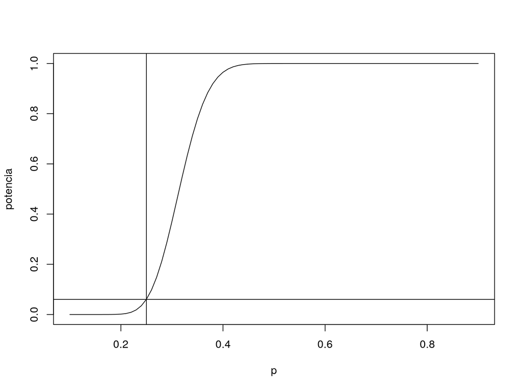

```r
potencia <- function(p){
  1-pnorm( (1.55 * sqrt(0.25*(1-0.25)/108)+ 0.25 -p)/sqrt(p*(1-p)/108))
}


p <- seq(0.1,0.9,0.01)
imp <- potencia(p)
plot(p, imp, type="l", xlab="p", ylab="potencia")
abline(v=0.25)
abline(h=0.06)
```

- Que pasa con la potencia si $n$ es más chico?
- Graficar la potencia para un $p$ fijo, digamos $0.36$ y $n$ variable.
- Regla: Cuando se usa el TCL para aproximar la distribución de una proporción, la aproximación se puede usar si $n*\hat p\geq 5$ y $n*(1-\hat p)\geq 5$

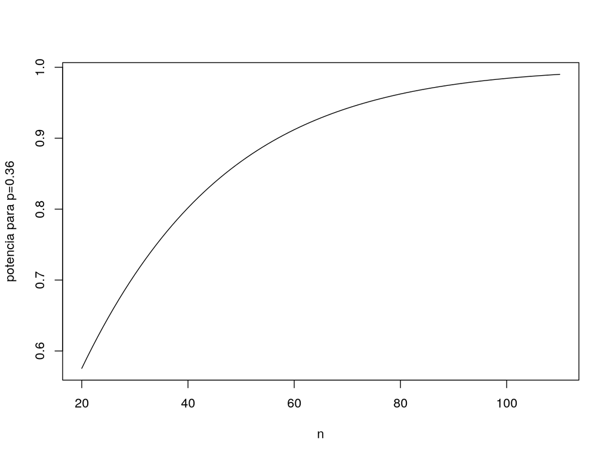

```r
potencia_036 <- function(n){
  p <- 0.36
  1-pnorm(1.55 * (sqrt(0.25*(1-0.25)/n)+ 0.25 -p)/sqrt(p*(1-p)/n))
}

n <- 20:110
imp <- potencia_036(n)
plot(n, imp, type="l", xlab="n", ylab="potencia para p=0.36")
```